# 3.4.171

## 3.3.171

An article by a researcher reported on a long-term study of the effects of hurricanes on tropical streams in forests. The study shows that one particular hurricane had a significant impact on stream water chemistry. The following table shows a sample of 10 ammonia fluxes in the first year after the hurricane. Data are in kilograms per hectare per year. Complete parts (a) through (e) below.

**Recommanded find quatiles mannually in Excel since there is inconsistent approach in R**

- even number of data set - type 5
- odd number of data set - type 1

First, we need to import the data from Excel. (For simplicity, this imports mannual by hand, we can get the same result by importing dataset from Excel)

```r
x <- c(88, 171, 64, 159, 89, 84, 180, 126, 123, 91)
x
```

```
##  [1]  88 171  64 159  89  84 180 126 123  91
```

**(a). Obtain and interpret the quartiles**

```r
summary(x, quantile.type=5)
```

```
##    Min. 1st Qu.  Median    Mean 3rd Qu.    Max.
##    64.0    88.0   107.0   117.5   159.0   180.0
```

```r
quantile(x, type=5)
```

```
##   0%  25%  50%  75% 100%
##   64   88  107  159  180
```

**(b).Determine and interpret the interquartile range (IQR).** We use the formula $IQR = Q_3-Q_1 $

```r
159-88
```

```
## [1] 71
```

**(c). Find and interpret the five-number summary.**

We can see the summary from part (a)

To interpret five-number summary, we plot boxplot of data

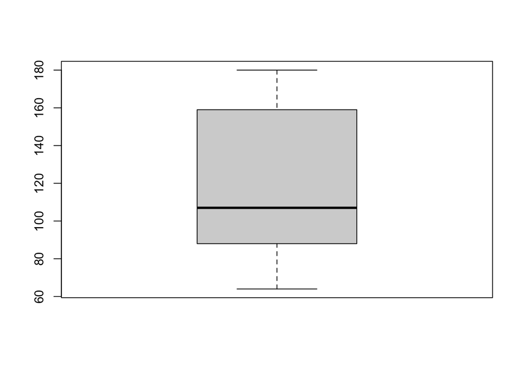

```r
boxplot(quantile(x, type=5))
```

**(d). Identify potential outliers, if any. Choose the correct answer below and, if necessary, fill in the answer box to complete your choice**

- Lower limit = $Q_1 - 1.5.IQR$
- Upper limit = $Q_3 + 1.5.IQR$

  Lower limit

```r
88 - 1.5 * 71
```

```
## [1] -18.5
```

Upper limit

```r
159 + 1.5 * 71
```

```
## [1] 265.5
```

Sort our data

```r
sort(x)
```

```
##  [1]  64  84  88  89  91 123 126 159 171 180
```

**Hope that helps!**